# Parcial fundamentos

Nombres: DYLAN GABRIEL GONZALEZ SANCHEZ y GERARDO ROCHA BENIGNO

**Entrega:** 16 de octubre antes de las 16:00 horas por Canvas.

**Instrucciones:**

- Tus respuestas deben ser claras y debes explicar los resultados, incluye también tus procedimientos/código de manera ordenada, y el código comentado.
- Se evaluará la presentación de resultados (calidad de las gráficas, tablas, …), revisa la sección de visualización en las notas.
- Se puede realizar individual o en parejas.
- Si tienes preguntas puedes escribirlas en el anuncio de canvas del examen, será el único medio para resolver dudas del examen.

## Pruebas de hipótesis

### 1. Pruebas de hipótesis: Ascorbato

Pacientes con cancer terminal avanzado en el estómago y mama se trataron con ascorbato para prolongar la supervivencia. Los datos `ascorbate` muestran la supervivencia en días. Trabaja con los datos en escala logarítimica.

```r
# Cargamos el conjunto de datos
# Traducimos los nombres de las columnas al español
ascorbate <- read_csv(".\\datos\\ascorbate.csv", show_col_types = FALSE) |>
  rename(estomago=stomach, mama = breast)


# Para realizar la prueba de hipótesis visual, es necesario  que el conjunto de datos tengala siguiente forma: columnas = c("dias de supervivencia", "tipo de cáncer")
ascorbato <- pivot_longer(ascorbate, cols=c(estomago, mama), names_to = "tipo_cancer", values_to = "dias")
```

Antes de realizar la prueba de hipótesis visual, visualizaremos la distribución de días de supervivencia de la muestra original. A primera vista, pareciera que la distribución del número de días tiende a valores más elevados para los pacientes con cancer de mamá que a los pacientes con cáncer de estómago, aunque la hipotesis visual nos ayudará a corroborar si esto es cierto o no.

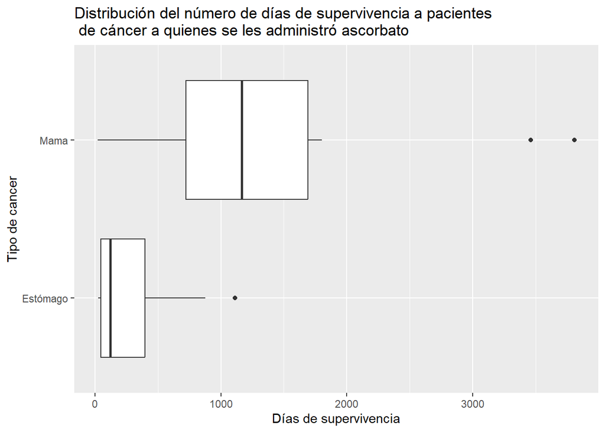

```r
ggplot(na.omit(ascorbato), aes(y = factor(tipo_cancer), x = dias)) +
  geom_boxplot() + labs(title='Distribución del número de días de supervivencia a pacientes\n de cáncer a quienes se les administró ascorbato',
                        x='Días de supervivencia', y ='Tipo de cancer') +
  scale_y_discrete(labels = c("estomago" = "Estómago", "mama" = "Mama"))
```

1. Realiza una prueba de hipótesis visual para comparar las mediciones de los dos grupos. Describe tus conclusiones.

```r
library(nullabor)
set.seed(2178827)
perms_tipo <- lineup(null_permute("tipo_cancer"), na.omit(ascorbato), n = 20)
```

```
## decrypt("fSL8 TXwX Ea eOHEwEOa 22")
```

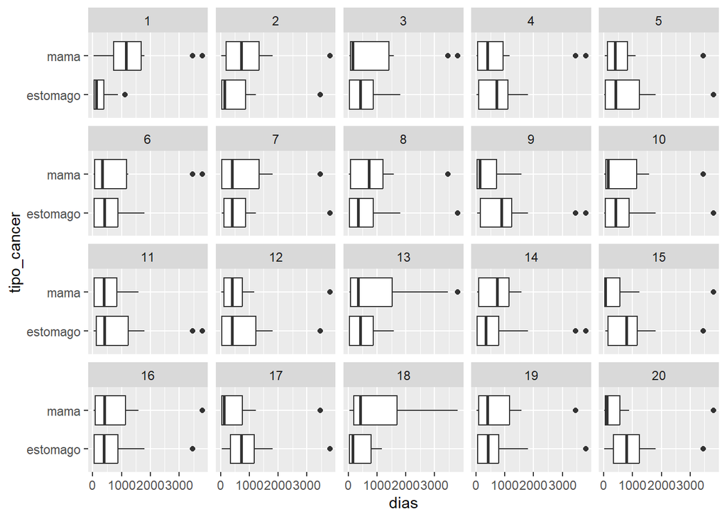

```r
ggplot(perms_tipo, aes(x = dias, y = tipo_cancer)) +
  geom_boxplot() +
  facet_wrap(~.sample)
```

2. Usa una prueba de permutación para examinar la hipótesis de que no hay diferencia en la media de los tiempos de supervivencia. Escribe la hipóteisis nula, hipótesis alterna, y reporta el valor $p$ de la prueba.

## 2. Bootstrap: Bioequivalencia

La bioequivalencia es un término utilizado en farmacocinética para evaluar la equivalencia terapéutica entre dos formulaciones de un medicamento que contiene el mismo principio activo o fármaco. Cuando una farmacéutica cambia una fórmula o desarrolla una nueva presentación de un medicamento ya disponible al público, requiere aprobación de la FDA para poder distribuirlo, para lograr esta aprobación debe demostrar que el nuevo medicamento es bioequivalente al medicamento ya aprobado, es así que se diseñan ensayos clínicos donde se compara la respuesta de los participantes al recibir las distintas formulaciones del medicamento.

En este ejercicio analizarás la bioequivalencia de una nueva tableta de Zolmitriptano de 5 mg en relación a tabletas aprobadas de 2.5 mg:

- En el ensayo clínico participaron 24 voluntarios saludables, cada uno se asignó de manera aleatoria para recibir la formulación de 5 mg (formulación a prueba) o dos tabletas de 2.5 mg (formulación referencia).
- Se recolectaron muestras de sangre antes de la dosis y durante las siguientes 24 horas.

Realiza lo siguiente:

1. Lee los datos `zolmitriptan-raw.txt`, las variables son:
   - `formulation` indica si la observación corresponde a formulación de refernecia o de prueba,
   - `subj` identifica al sujeto,
   - `seq` toma dos valores 1 indica que el sujeto se evaluó tomando la formulación de tratamiento primero y después la de referencia, 2 indica el caso contrario,
   - `prd` indica el periodo (1 o 2),
   - las variables `HRXX` indican la medición (concentración de Zolmitriptano en mCG/ml) para la hora XX (HR00 corresponde a la hora cero, HR05 a media hora, HR10 a una hora,…, HR240 a 24 horas). Desafortunadamente estos datos crudos están truncados y para algunos sujetos (1, 3, 5, 8, 9, 12, 16, 17, 19, 22, 23) no tenemos las mediciones del tratamiento de referencia, sin embargo, podemos usar la información disponible para entender como se calculan las métricas.

```r
zolmitriptan_raw <- read_delim("datos/zolmitriptan-raw.txt",
    "\t", escape_double = FALSE, trim_ws = TRUE)
```

1. Grafica la concentración del medicamento por hora. Debes graficar en el eje horizontal la hora, en el eje vertical la concentración para cada persona, bajo cada tratamiento. Un ejemplo de lo que debes hacer es [esta gráfica](https://en.wikipedia.org/wiki/Bioequivalence#/media/File:Bupropion_bioequivalency_comparison.svg), con la diferencia que la curva de Wikipedia es el promedio sobre todos los individuos y tu graficarás una para cada uno. ¿Qué puedes ver en las gráficas?

Para comprobar bioequivalencia la FDA solicita que el medicamento de prueba tenga un comportamiento similar al del medicamento de referencia. Para ello se compara la máxima concentración de medicamento (CMAX), el tiempo que tarda el individuo en alcanzar las concentración máxima en sangre (TMAX), y el área bajo la curva de concentración contra tiempofci (AUC, que acabas de graficar). En particular para que la FDA concluya bioequivalencia se requiere que para cada medición (CMAX, TMAX y AUC) un intervalo de 90% de confianza para el cociente $\mu_T/\mu_R$ de la media del tratamiento de prueba $\mu_T$ y la media de la referencia $\mu_R$ esté contenido en el intervalo $(80\%, 125\%)$. En este ejercicio usarás bootstrap para calcular un intervalo de confianza para el cociente de las medias de AUC.

2. Calcula el AUC para cada individuo en cada tratamiento disponible, usa la fórmula de área trapezoidal:
   $$AUC =
   \sum_{\tau=1}^k(c_\tau + c_{\tau−1}) × (t_\tau − t_{\tau-1}) /
   2$$
   donde $c$ es la concentración y $t$ son las horas. Tip: Si usas las funciones de dplyr puede resultar útil usar `lag()`. Presenta una tabla con tus resultados.

Para los siguientes incisos usa los datos zolmitriptan.csv, para el $i$-ésimo individuo `subj` tienes mediciones de AUC bajo tratamiento y referencia, denotemos a este par $x_i=(auc_{Ti}, auc_{Ri})$, suponiendo que las $x_i$ se obuvieron de manera aleatoria de una distribución bivariada $P$, entonces la cantidad poblacional de interés es el parámetro $\theta = \mu_T/\mu_R$.

3. Calcula el estimador *plug-in* de $\theta$.
4. Usa bootstrap para generar un intervalo del 90% de confianza para $\theta$, ¿la nueva tableta cumple el criterio de bioequivalencia de la FDA?

### 3. Bootstrap encuestas

En este ejercicio utilizarás la Encuesta Nacional sobre Disponibilidad y Uso de Tecnologías de la Información en los Hogares (ENDUTIH) para estimar a nivel nacional:

- la proporción de hogares que tienen acceso a internet.
- la proporción de hogares con teléfono fijo.
- la proporción de hogares con teléfono móvil.
1. Reporta estimaciones puntuales e intervalos de confianza del 95% (utilizando bootstrap de Rao y Wu, puedes usar los paquetes survey o srvyr).
2. Elige una de las métricas de arriba y calcula intervalos de confianza por estado, grafica los intervalos y discute los resultados.